# Motor Trend Data Analysis

Philip Bulsink

2017-02-18

# How does Transmission Type Effect Milage?

## Executive Summary

This report will outline the effect of transmission type (automatic vs. manual) on gas milage. The influence of other variables will be investigated as well as confounding factors. It is shown that, with all other factors taken into consideration, no milage improvement is seen for manual cars.

## Introduction

```r
data("mtcars")
```

## Data Preparation

A few of the variables we will be investigating in this report can be considered ‘factors’, that is, of a non-numeric or a counted type. This includes transmission type, and may include number of gears, number of carburetors, number of cylinders, or if the engine is straight or V shaped.

```r
mtcars$am<-factor(mtcars$am, labels = c("Automatic", "Manual"))
mtcars$vs<-factor(mtcars$vs, labels = c("V", "Straight"))
mtcars$cyl<-as.factor(mtcars$cyl)
mtcars$carb<-as.factor(mtcars$carb)
mtcars$gear<-as.factor(mtcars$gear)
```

## Data Exploration

A first glance at the data suggests that there is an effect on milage (mpg) by transimission type (am), whereby manual transmissions have better (higher) gas milage. See a plot of this data in Appendix 1.

We can quantify this by regressing the data over this factor:

```r
fit1<-lm(mpg ~ am, data=mtcars)
summary(fit1)$coef
```

```
##             Estimate Std. Error t value Pr(>|t|)
## (Intercept)     17.1        1.1    15.2  1.1e-15
## amManual         7.2        1.8     4.1  2.9e-04
```

Thus, we can see that, taking no other factors into play, the average milage of cars with a manual transmission is approximately 7.24 better than that of an automatic transmission, which has an average milage of 17.15. The p value for this estimate is very low, at $2.85\times 10^{-4}$, allowing us to reject the null hypothesis that there is no difference.

## Detailed Data Analysis

What if the enhancement of milage in manual transmissions is due to some other factor? For example, in Appendix 2, we show the milage as a function of transmission type, but broken up by cylinder. For 8 cylinder cars, it looks like manual may not be any better than automatic, contrary to our above discovery. We’ll test for other factors like this as well, before validating which matter.

```r
fit2 <- lm(mpg~am + cyl, data=mtcars)
```

If we include cylinders in our model, we then find that cars with a manual transmission is approximately 2.56 better than that of an automatic transmission, which has an average milage of 24.8. The benefit of a manual transmission is much reduced when considering cylinder count. Each of the possible models is built below, followed by an ANOVA analysis to identify which factors are significant.

```r
fit3 <- lm(mpg~am + cyl + wt, data=mtcars)
fit4 <- lm(mpg~am + cyl + wt + gear, data=mtcars)
fit5 <- lm(mpg~am + cyl + wt + gear + hp, data=mtcars)
fit6 <- lm(mpg~am + cyl + wt + gear + hp + carb, data=mtcars)
fit7 <- lm(mpg~am + cyl + wt + gear + hp + carb + disp, data=mtcars)
fit8 <- lm(mpg~am + cyl + wt + gear + hp + carb + disp + drat, data=mtcars)
fit9 <- lm(mpg~am + cyl + wt + gear + hp + carb + disp + drat + vs, data=mtcars)
fit10 <- lm(mpg~am + cyl + wt + gear + hp + carb + disp + drat + vs + qsec, data=mtcars)

anova(fit1, fit2, fit3, fit4, fit5, fit6, fit7, fit8, fit9, fit10)[1:6]
```

```
##    Res.Df RSS Df Sum of Sq     F  Pr(>F)
## 1      30 721
## 2      28 264  2       456 28.43 7.9e-06 ***
## 3      27 183  1        82 10.16  0.0061 **
## 4      25 175  2         8  0.51  0.6106
## 5      24 150  1        25  3.13  0.0972 .
## 6      19 140  5        10  0.25  0.9329
## 7      18 128  1        12  1.46  0.2456
## 8      17 126  1         2  0.26  0.6165
## 9      16 122  1         4  0.52  0.4839
## 10     15 120  1         1  0.15  0.6997
## ---
## Signif. codes:  0 '***' 0.001 '**' 0.01 '*' 0.05 '.' 0.1 ' ' 1
```

We can see that only the numbers of cylinders, and the weight affect the model in a statistically significant way, beyond the automatic/manual correllation. The rest of the variables, while reducing model variance, are not significant predictors.

## Final Model

Knowing that we can fit the best model with by including transmission type, cylinder count, and weight, we build the final model:

```r
#code
fitfinal<-lm(mpg~am+cyl+wt, data=mtcars)
summary(fitfinal)$coef
```

```
##             Estimate Std. Error t value Pr(>|t|)
## (Intercept)    33.75       2.81   12.00  2.5e-12
## amManual        0.15       1.30    0.12  9.1e-01
## cyl6           -4.26       1.41   -3.02  5.5e-03
## cyl8           -6.08       1.68   -3.61  1.2e-03
## wt             -3.15       0.91   -3.47  1.8e-03
```

# Appendices

## Appendix 1: Plot of milage vs. transmission type:

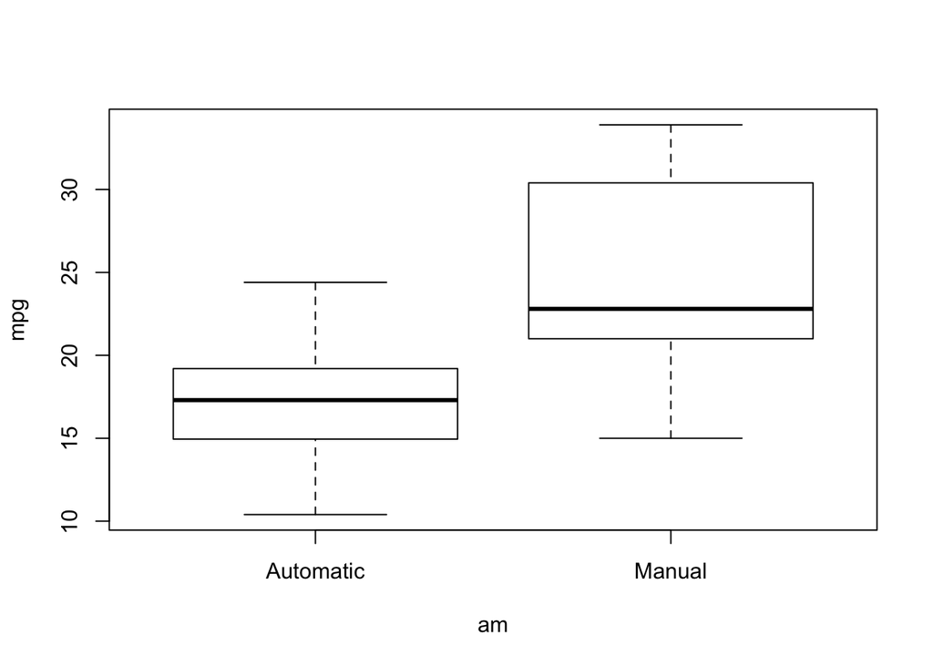

```r
plot(mpg~am, data=mtcars)
```

## Appendix 2: Plot of milage vs. cylinder count and transmission type:

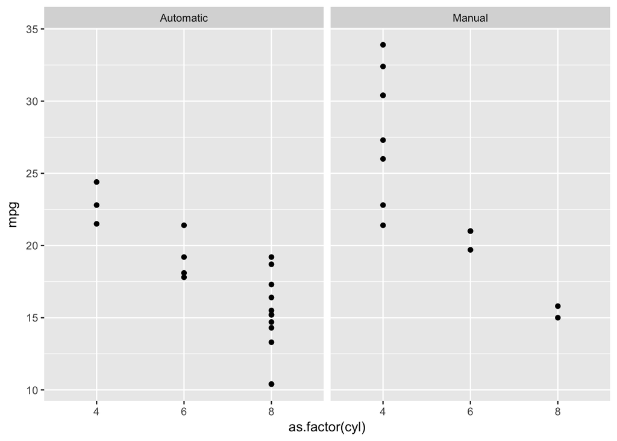

```r
ggplot(mtcars, aes(x=as.factor(cyl), y=mpg)) + geom_point() + facet_grid(.~am)
```

## Appendix 3: Residuals Diagnostic Plots

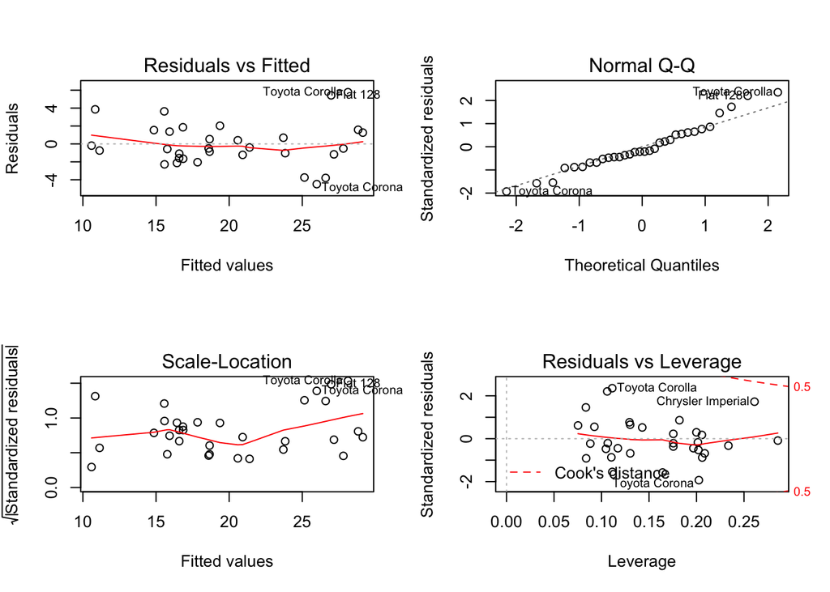

```r
par(mfrow=c(2,2))
plot(fitfinal)
```